# House Price Analysis - Advanced Regression techniques.

```python
#Import Libraries
import numpy as np
import pandas as pd
import matplotlib.pyplot as plt
import seaborn as sns
from scipy.stats import ttest_ind_from_stats
import statsmodels.api as sm
from statsmodels.formula.api import ols
from sklearn.preprocessing import LabelEncoder, MinMaxScaler
from sklearn.linear_model import LinearRegression
from sklearn.linear_model import Ridge, Lasso, RidgeCV, LassoCV, ElasticNet
from sklearn.model_selection import cross_val_score
from sklearn.model_selection import GridSearchCV
from sklearn.model_selection import train_test_split
from sklearn import metrics
from sklearn.ensemble import RandomForestRegressor
from sklearn.tree import DecisionTreeRegressor
import xgboost as xgb
import warnings
import shap
```

```python
warnings.filterwarnings('ignore')
```

# Load data

```python
traindf = pd.read_csv('/Users/bharatdivvela/Downloads/house-prices-advanced-regression-techniques/train.csv')
testdf = pd.read_csv('/Users/bharatdivvela/Downloads/house-prices-advanced-regression-techniques/test.csv')
totaldf = pd.concat([traindf,testdf],axis=0,sort=True)
```

```python
#Get the Shape of data
totaldf.shape
```

```
(2919, 81)
```

```python
totaldf.columns
```

```
Index(['1stFlrSF', '2ndFlrSF', '3SsnPorch', 'Alley', 'BedroomAbvGr',
       'BldgType', 'BsmtCond', 'BsmtExposure', 'BsmtFinSF1', 'BsmtFinSF2',
       'BsmtFinType1', 'BsmtFinType2', 'BsmtFullBath', 'BsmtHalfBath',
       'BsmtQual', 'BsmtUnfSF', 'CentralAir', 'Condition1', 'Condition2',
       'Electrical', 'EnclosedPorch', 'ExterCond', 'ExterQual', 'Exterior1st',
       'Exterior2nd', 'Fence', 'FireplaceQu', 'Fireplaces', 'Foundation',
       'FullBath', 'Functional', 'GarageArea', 'GarageCars', 'GarageCond',
       'GarageFinish', 'GarageQual', 'GarageType', 'GarageYrBlt', 'GrLivArea',
       'HalfBath', 'Heating', 'HeatingQC', 'HouseStyle', 'Id', 'KitchenAbvGr',
       'KitchenQual', 'LandContour', 'LandSlope', 'LotArea', 'LotConfig',
       'LotFrontage', 'LotShape', 'LowQualFinSF', 'MSSubClass', 'MSZoning',
       'MasVnrArea', 'MasVnrType', 'MiscFeature', 'MiscVal', 'MoSold',
       'Neighborhood', 'OpenPorchSF', 'OverallCond', 'OverallQual',
       'PavedDrive', 'PoolArea', 'PoolQC', 'RoofMatl', 'RoofStyle',
       'SaleCondition', 'SalePrice', 'SaleType', 'ScreenPorch', 'Street',
       'TotRmsAbvGrd', 'TotalBsmtSF', 'Utilities', 'WoodDeckSF', 'YearBuilt',
       'YearRemodAdd', 'YrSold'],
      dtype='object')
```

```python
#check Duplicates
totaldf.drop_duplicates(inplace = True)
```

```python
totaldf.describe()
```

|  | 1stFlrSF | 2ndFlrSF | 3SsnPorch | BedroomAbvGr | BsmtFinSF1 | BsmtFinSF2 | BsmtFullBath | BsmtHalfBath | BsmtUnfSF | EnclosedPorch | ... | OverallQual | PoolArea | SalePrice | ScreenPorch | TotRmsAbvGrd | TotalBsmtSF | WoodDeckSF | YearBuilt | YearRemodAdd | YrSold |
| --- | --- | --- | --- | --- | --- | --- | --- | --- | --- | --- | --- | --- | --- | --- | --- | --- | --- | --- | --- | --- | --- |
| count | 2919.000000 | 2919.000000 | 2919.000000 | 2919.000000 | 2918.000000 | 2918.000000 | 2917.000000 | 2917.000000 | 2918.000000 | 2919.000000 | ... | 2919.000000 | 2919.000000 | 1460.000000 | 2919.000000 | 2919.000000 | 2918.000000 | 2919.000000 | 2919.000000 | 2919.000000 | 2919.000000 |
| mean | 1159.581706 | 336.483727 | 2.602261 | 2.860226 | 441.423235 | 49.582248 | 0.429894 | 0.061364 | 560.772104 | 23.098321 | ... | 6.089072 | 2.251799 | 180921.195890 | 16.062350 | 6.451524 | 1051.777587 | 93.709832 | 1971.312778 | 1984.264474 | 2007.792737 |
| std | 392.362079 | 428.701456 | 25.188169 | 0.822693 | 455.610826 | 169.205611 | 0.524736 | 0.245687 | 439.543659 | 64.244246 | ... | 1.409947 | 35.663946 | 79442.502883 | 56.184365 | 1.569379 | 440.766258 | 126.526589 | 30.291442 | 20.894344 | 1.314964 |
| min | 334.000000 | 0.000000 | 0.000000 | 0.000000 | 0.000000 | 0.000000 | 0.000000 | 0.000000 | 0.000000 | 0.000000 | ... | 1.000000 | 0.000000 | 34900.000000 | 0.000000 | 2.000000 | 0.000000 | 0.000000 | 1872.000000 | 1950.000000 | 2006.000000 |
| 25% | 876.000000 | 0.000000 | 0.000000 | 2.000000 | 0.000000 | 0.000000 | 0.000000 | 0.000000 | 220.000000 | 0.000000 | ... | 5.000000 | 0.000000 | 129975.000000 | 0.000000 | 5.000000 | 793.000000 | 0.000000 | 1953.500000 | 1965.000000 | 2007.000000 |
| 50% | 1082.000000 | 0.000000 | 0.000000 | 3.000000 | 368.500000 | 0.000000 | 0.000000 | 0.000000 | 467.000000 | 0.000000 | ... | 6.000000 | 0.000000 | 163000.000000 | 0.000000 | 6.000000 | 989.500000 | 0.000000 | 1973.000000 | 1993.000000 | 2008.000000 |
| 75% | 1387.500000 | 704.000000 | 0.000000 | 3.000000 | 733.000000 | 0.000000 | 1.000000 | 0.000000 | 805.500000 | 0.000000 | ... | 7.000000 | 0.000000 | 214000.000000 | 0.000000 | 7.000000 | 1302.000000 | 168.000000 | 2001.000000 | 2004.000000 | 2009.000000 |
| max | 5095.000000 | 2065.000000 | 508.000000 | 8.000000 | 5644.000000 | 1526.000000 | 3.000000 | 2.000000 | 2336.000000 | 1012.000000 | ... | 10.000000 | 800.000000 | 755000.000000 | 576.000000 | 15.000000 | 6110.000000 | 1424.000000 | 2010.000000 | 2010.000000 | 2010.000000 |

8 rows × 38 columns

```python
#Get Info
totaldf.info()
```

```
<class 'pandas.core.frame.DataFrame'>
Int64Index: 2919 entries, 0 to 1458
Data columns (total 81 columns):
1stFlrSF         2919 non-null int64
2ndFlrSF         2919 non-null int64
3SsnPorch        2919 non-null int64
Alley            198 non-null object
BedroomAbvGr     2919 non-null int64
BldgType         2919 non-null object
BsmtCond         2837 non-null object
BsmtExposure     2837 non-null object
BsmtFinSF1       2918 non-null float64
BsmtFinSF2       2918 non-null float64
BsmtFinType1     2840 non-null object
BsmtFinType2     2839 non-null object
BsmtFullBath     2917 non-null float64
BsmtHalfBath     2917 non-null float64
BsmtQual         2838 non-null object
BsmtUnfSF        2918 non-null float64
CentralAir       2919 non-null object
Condition1       2919 non-null object
Condition2       2919 non-null object
Electrical       2918 non-null object
EnclosedPorch    2919 non-null int64
ExterCond        2919 non-null object
ExterQual        2919 non-null object
Exterior1st      2918 non-null object
Exterior2nd      2918 non-null object
Fence            571 non-null object
FireplaceQu      1499 non-null object
Fireplaces       2919 non-null int64
Foundation       2919 non-null object
FullBath         2919 non-null int64
Functional       2917 non-null object
GarageArea       2918 non-null float64
GarageCars       2918 non-null float64
GarageCond       2760 non-null object
GarageFinish     2760 non-null object
GarageQual       2760 non-null object
GarageType       2762 non-null object
```

[output cut: 31 more lines]

```
RoofStyle        2919 non-null object
SaleCondition    2919 non-null object
SalePrice        1460 non-null float64
SaleType         2918 non-null object
ScreenPorch      2919 non-null int64
Street           2919 non-null object
TotRmsAbvGrd     2919 non-null int64
TotalBsmtSF      2918 non-null float64
Utilities        2917 non-null object
WoodDeckSF       2919 non-null int64
YearBuilt        2919 non-null int64
YearRemodAdd     2919 non-null int64
YrSold           2919 non-null int64
dtypes: float64(12), int64(26), object(43)
memory usage: 1.8+ MB
```

```python
traindf.head()
```

|  | Id | MSSubClass | MSZoning | LotFrontage | LotArea | Street | Alley | LotShape | LandContour | Utilities | ... | PoolArea | PoolQC | Fence | MiscFeature | MiscVal | MoSold | YrSold | SaleType | SaleCondition | SalePrice |
| --- | --- | --- | --- | --- | --- | --- | --- | --- | --- | --- | --- | --- | --- | --- | --- | --- | --- | --- | --- | --- | --- |
| 0 | 1 | 60 | RL | 65.0 | 8450 | Pave | NaN | Reg | Lvl | AllPub | ... | 0 | NaN | NaN | NaN | 0 | 2 | 2008 | WD | Normal | 208500 |
| 1 | 2 | 20 | RL | 80.0 | 9600 | Pave | NaN | Reg | Lvl | AllPub | ... | 0 | NaN | NaN | NaN | 0 | 5 | 2007 | WD | Normal | 181500 |
| 2 | 3 | 60 | RL | 68.0 | 11250 | Pave | NaN | IR1 | Lvl | AllPub | ... | 0 | NaN | NaN | NaN | 0 | 9 | 2008 | WD | Normal | 223500 |
| 3 | 4 | 70 | RL | 60.0 | 9550 | Pave | NaN | IR1 | Lvl | AllPub | ... | 0 | NaN | NaN | NaN | 0 | 2 | 2006 | WD | Abnorml | 140000 |
| 4 | 5 | 60 | RL | 84.0 | 14260 | Pave | NaN | IR1 | Lvl | AllPub | ... | 0 | NaN | NaN | NaN | 0 | 12 | 2008 | WD | Normal | 250000 |

5 rows × 81 columns

# Exploration

## Sale Price

```
{'whiskers': [<matplotlib.lines.Line2D at 0x11d946910>,
 'caps': [<matplotlib.lines.Line2D at 0x11d94f3d0>,
 'boxes': [<matplotlib.lines.Line2D at 0x11d946310>],
 'medians': [<matplotlib.lines.Line2D at 0x11d94fe90>],
 'fliers': [<matplotlib.lines.Line2D at 0x11d955410>],
 'means': []}
```

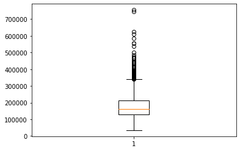

```python
plt.boxplot(traindf['SalePrice'])
```

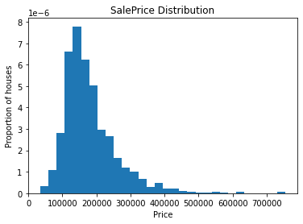

```python
plt.hist(traindf['SalePrice'],bins=30,density=True)
plt.xlabel('Price')
plt.ylabel('Proportion of houses')
plt.title('SalePrice Distribution')
```

The curve is skewed towards right suggesting some expensive houses.

## Lot Area

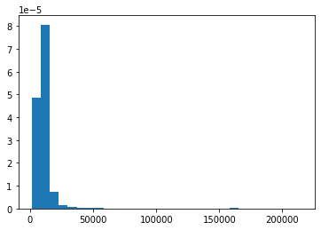

```python
_ = plt.hist(traindf['LotArea'],bins=30,density = True)
```

There is too much of data at the left. Let's apply logarithm

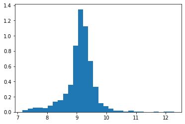

```python
_ = plt.hist(np.log(traindf['LotArea']),bins=30,density = True)
```

## No of Rooms

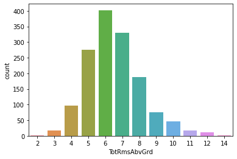

```python
sns.countplot(traindf['TotRmsAbvGrd'])
```

```python
#SalePrice Vs No of Rooms
lm= ols('SalePrice ~ TotRmsAbvGrd', data = traindf).fit()
table= sm.stats.anova_lm(lm)
print(table)
```

```
                  df        sum_sq       mean_sq           F         PR(>F)
TotRmsAbvGrd     1.0  2.622969e+12  2.622969e+12  580.762801  2.772281e-108
Residual      1458.0  6.584942e+12  4.516421e+09         NaN            NaN
```

F-Stat of 580 means No of Rooms influence the SalePrice

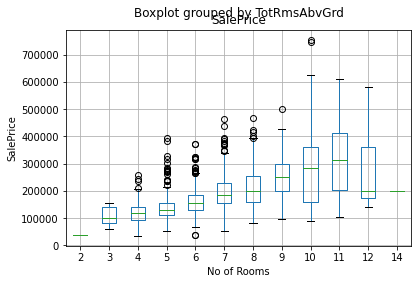

```python
traindf.boxplot(column = 'SalePrice', by = 'TotRmsAbvGrd')
plt.xlabel('No of Rooms')
plt.ylabel('SalePrice')
```

## Car Spaces

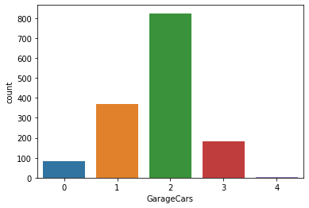

```python
#No of Car Spaces
sns.countplot(traindf['GarageCars'])
```

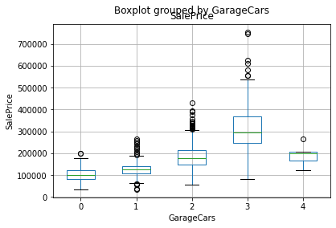

```python
#No of Car Spaces Vs SalePrice
#H0: The mean SalePrice does not differ with Car Spaces
#H1: The meaan SalePrice differ with Car Spaces
traindf.boxplot(column = 'SalePrice', by = 'GarageCars')
plt.ylabel('SalePrice')
```

```python
mean1 = traindf[traindf['GarageCars']==1]['SalePrice'].mean()
std1 = traindf[traindf['GarageCars']==1]['SalePrice'].std()
nobs1 = traindf[traindf['GarageCars']==1]['SalePrice'].count()
mean2 = traindf[traindf['GarageCars']==2]['SalePrice'].mean()
std2 = traindf[traindf['GarageCars']==2]['SalePrice'].std()
nobs2 = traindf[traindf['GarageCars']==2]['SalePrice'].count()
ttest_ind_from_stats(mean1, std1, nobs1, mean2, std2, nobs2, equal_var=False)
```

```
Ttest_indResult(statistic=-23.263431165660258, pvalue=8.93540934556563e-98)
```

The t statistic is too large for a significance of 0.05. So, the car space affects the SalePrice significantly.

## Pool Area

```python
#H0: the SalePrice means of two groups are indifferent
#Ha: the SalePrice means of two groups are different
observed_mean_diff = traindf[traindf['PoolArea'] > 0]['SalePrice'].mean() - traindf[traindf['PoolArea'] == 0]['SalePrice'].mean()
print('Observed diff:',observed_mean_diff)
mean_diff = []
for i in range(1000):
    mean_pool = traindf[traindf['PoolArea'] > 0]['SalePrice'].sample(frac=1,replace=True).mean()
    mean_no_pool = traindf[traindf['PoolArea'] == 0]['SalePrice'].sample(frac=1,replace=True).mean()
    mean_diff.append(mean_pool - mean_no_pool)

confidence_interval = np.percentile(mean_diff,[0.025,0.975])
print(confidence_interval)
```

```
Observed diff: 107733.90797365058
[-11614.16239699   2670.3629651 ]
```

## Central Air

```python
observed_mean_diff = traindf[traindf['CentralAir'] == 'Y']['SalePrice'].mean() - traindf[traindf['CentralAir'] == 'N']['SalePrice'].mean()
print('Observed diff:',observed_mean_diff)
mean_diff = []
for i in range(1000):
    mean_Air = traindf[traindf['CentralAir'] == 'Y']['SalePrice'].sample(frac=1,replace=True).mean()
    mean_no_Air = traindf[traindf['CentralAir'] == 'N']['SalePrice'].sample(frac=1,replace=True).mean()
    mean_diff.append(mean_Air - mean_no_Air)

confidence_interval = np.percentile(mean_diff,[0.025,0.975])
print(confidence_interval)
```

```
Observed diff: 80922.63620589937
[65235.40737106 70092.9829711 ]
```

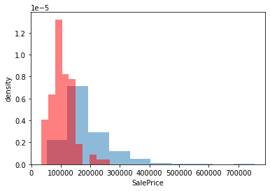

```python
plt.subplots()
ax = plt.hist(traindf[traindf['CentralAir'] == 'Y']['SalePrice'],density=True,alpha=0.5)
_ = plt.hist(traindf[traindf['CentralAir'] == 'N']['SalePrice'],density=True, alpha=0.5, color = 'red' )
_ = plt.xlabel('SalePrice')
_ = plt.ylabel('density')
```

The saleprice depends on CentralAir.

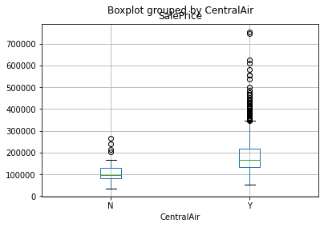

```python
traindf.boxplot(column = 'SalePrice', by = 'CentralAir')
```

## Age

```python
#Age:
#traindf['Age'] = traindf['YrSold'] - traindf['YearBuilt']
#traindf.groupby('Age')['SalePrice'].mean().plot()
```

```python
#lm= ols('SalePrice ~ Age', data = traindf).fit()
#table= sm.stats.anova_lm(lm)
#print(table)
```

## FirePlaces

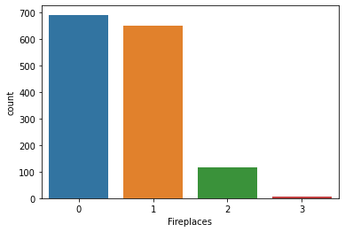

```python
sns.countplot(traindf['Fireplaces'])
```

```python
#H0: Fireplaces does not influence SalePrice
#Ha: Fireplaces influence SalePrice
#Anova test for Fireplaces
lm= ols('SalePrice ~ Fireplaces', data = traindf).fit()
table= sm.stats.anova_lm(lm)
print(table)
```

```
                df        sum_sq       mean_sq           F        PR(>F)
Fireplaces     1.0  2.007532e+12  2.007532e+12  406.503866  6.141487e-80
Residual    1458.0  7.200379e+12  4.938532e+09         NaN           NaN
```

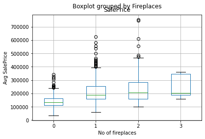

```python
traindf.boxplot(column = 'SalePrice', by = 'Fireplaces')

_ = plt.xlabel('No of fireplaces')
_ = plt.ylabel('Avg SalePrice')
```

The fire places influence SalePrice

## Sale Condition

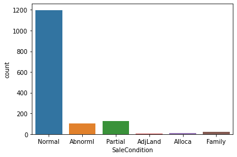

```python
sns.countplot(traindf['SaleCondition'])
```

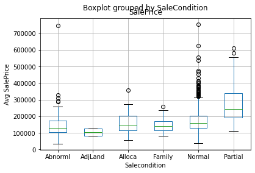

```python
traindf.boxplot(column = 'SalePrice', by = 'SaleCondition')

_ = plt.xlabel('Salecondition')
_ = plt.ylabel('Avg SalePrice')
```

```python
lm= ols('SalePrice ~ SaleCondition', data = traindf).fit()
table= sm.stats.anova_lm(lm)
print(table)
```

```
                   df        sum_sq       mean_sq          F        PR(>F)
SaleCondition     5.0  1.247649e+12  2.495298e+11  45.578428  7.988268e-44
Residual       1454.0  7.960263e+12  5.474734e+09        NaN           NaN
```

The SaleCondition influence SalePrice

## Correlation Matrix

```python
corr_matrix = traindf.corr()
corr_matrix[abs(corr_matrix) > 0.4]
```

|  | Id | MSSubClass | LotFrontage | LotArea | OverallQual | OverallCond | YearBuilt | YearRemodAdd | MasVnrArea | BsmtFinSF1 | ... | WoodDeckSF | OpenPorchSF | EnclosedPorch | 3SsnPorch | ScreenPorch | PoolArea | MiscVal | MoSold | YrSold | SalePrice |
| --- | --- | --- | --- | --- | --- | --- | --- | --- | --- | --- | --- | --- | --- | --- | --- | --- | --- | --- | --- | --- | --- |
| Id | 1.0 | NaN | NaN | NaN | NaN | NaN | NaN | NaN | NaN | NaN | ... | NaN | NaN | NaN | NaN | NaN | NaN | NaN | NaN | NaN | NaN |
| MSSubClass | NaN | 1.0 | NaN | NaN | NaN | NaN | NaN | NaN | NaN | NaN | ... | NaN | NaN | NaN | NaN | NaN | NaN | NaN | NaN | NaN | NaN |
| LotFrontage | NaN | NaN | 1.000000 | 0.426095 | NaN | NaN | NaN | NaN | NaN | NaN | ... | NaN | NaN | NaN | NaN | NaN | NaN | NaN | NaN | NaN | NaN |
| LotArea | NaN | NaN | 0.426095 | 1.000000 | NaN | NaN | NaN | NaN | NaN | NaN | ... | NaN | NaN | NaN | NaN | NaN | NaN | NaN | NaN | NaN | NaN |
| OverallQual | NaN | NaN | NaN | NaN | 1.000000 | NaN | 0.572323 | 0.550684 | 0.411876 | NaN | ... | NaN | NaN | NaN | NaN | NaN | NaN | NaN | NaN | NaN | 0.790982 |
| OverallCond | NaN | NaN | NaN | NaN | NaN | 1.0 | NaN | NaN | NaN | NaN | ... | NaN | NaN | NaN | NaN | NaN | NaN | NaN | NaN | NaN | NaN |
| YearBuilt | NaN | NaN | NaN | NaN | 0.572323 | NaN | 1.000000 | 0.592855 | NaN | NaN | ... | NaN | NaN | NaN | NaN | NaN | NaN | NaN | NaN | NaN | 0.522897 |
| YearRemodAdd | NaN | NaN | NaN | NaN | 0.550684 | NaN | 0.592855 | 1.000000 | NaN | NaN | ... | NaN | NaN | NaN | NaN | NaN | NaN | NaN | NaN | NaN | 0.507101 |
| MasVnrArea | NaN | NaN | NaN | NaN | 0.411876 | NaN | NaN | NaN | 1.000000 | NaN | ... | NaN | NaN | NaN | NaN | NaN | NaN | NaN | NaN | NaN | 0.477493 |
| BsmtFinSF1 | NaN | NaN | NaN | NaN | NaN | NaN | NaN | NaN | NaN | 1.000000 | ... | NaN | NaN | NaN | NaN | NaN | NaN | NaN | NaN | NaN | NaN |
| BsmtFinSF2 | NaN | NaN | NaN | NaN | NaN | NaN | NaN | NaN | NaN | NaN | ... | NaN | NaN | NaN | NaN | NaN | NaN | NaN | NaN | NaN | NaN |
| BsmtUnfSF | NaN | NaN | NaN | NaN | NaN | NaN | NaN | NaN | NaN | -0.495251 | ... | NaN | NaN | NaN | NaN | NaN | NaN | NaN | NaN | NaN | NaN |
| TotalBsmtSF | NaN | NaN | NaN | NaN | 0.537808 | NaN | NaN | NaN | NaN | 0.522396 | ... | NaN | NaN | NaN | NaN | NaN | NaN | NaN | NaN | NaN | 0.613581 |
| 1stFlrSF | NaN | NaN | 0.457181 | NaN | 0.476224 | NaN | NaN | NaN | NaN | 0.445863 | ... | NaN | NaN | NaN | NaN | NaN | NaN | NaN | NaN | NaN | 0.605852 |
| 2ndFlrSF | NaN | NaN | NaN | NaN | NaN | NaN | NaN | NaN | NaN | NaN | ... | NaN | NaN | NaN | NaN | NaN | NaN | NaN | NaN | NaN | NaN |
| LowQualFinSF | NaN | NaN | NaN | NaN | NaN | NaN | NaN | NaN | NaN | NaN | ... | NaN | NaN | NaN | NaN | NaN | NaN | NaN | NaN | NaN | NaN |
| GrLivArea | NaN | NaN | 0.402797 | NaN | 0.593007 | NaN | NaN | NaN | NaN | NaN | ... | NaN | NaN | NaN | NaN | NaN | NaN | NaN | NaN | NaN | 0.708624 |
| BsmtFullBath | NaN | NaN | NaN | NaN | NaN | NaN | NaN | NaN | NaN | 0.649212 | ... | NaN | NaN | NaN | NaN | NaN | NaN | NaN | NaN | NaN | NaN |
| BsmtHalfBath | NaN | NaN | NaN | NaN | NaN | NaN | NaN | NaN | NaN | NaN | ... | NaN | NaN | NaN | NaN | NaN | NaN | NaN | NaN | NaN | NaN |
| FullBath | NaN | NaN | NaN | NaN | 0.550600 | NaN | 0.468271 | 0.439046 | NaN | NaN | ... | NaN | NaN | NaN | NaN | NaN | NaN | NaN | NaN | NaN | 0.560664 |
| HalfBath | NaN | NaN | NaN | NaN | NaN | NaN | NaN | NaN | NaN | NaN | ... | NaN | NaN | NaN | NaN | NaN | NaN | NaN | NaN | NaN | NaN |
| BedroomAbvGr | NaN | NaN | NaN | NaN | NaN | NaN | NaN | NaN | NaN | NaN | ... | NaN | NaN | NaN | NaN | NaN | NaN | NaN | NaN | NaN | NaN |
| KitchenAbvGr | NaN | NaN | NaN | NaN | NaN | NaN | NaN | NaN | NaN | NaN | ... | NaN | NaN | NaN | NaN | NaN | NaN | NaN | NaN | NaN | NaN |
| TotRmsAbvGrd | NaN | NaN | NaN | NaN | 0.427452 | NaN | NaN | NaN | NaN | NaN | ... | NaN | NaN | NaN | NaN | NaN | NaN | NaN | NaN | NaN | 0.533723 |
| Fireplaces | NaN | NaN | NaN | NaN | NaN | NaN | NaN | NaN | NaN | NaN | ... | NaN | NaN | NaN | NaN | NaN | NaN | NaN | NaN | NaN | 0.466929 |
| GarageYrBlt | NaN | NaN | NaN | NaN | 0.547766 | NaN | 0.825667 | 0.642277 | NaN | NaN | ... | NaN | NaN | NaN | NaN | NaN | NaN | NaN | NaN | NaN | 0.486362 |
| GarageCars | NaN | NaN | NaN | NaN | 0.600671 | NaN | 0.537850 | 0.420622 | NaN | NaN | ... | NaN | NaN | NaN | NaN | NaN | NaN | NaN | NaN | NaN | 0.640409 |
| GarageArea | NaN | NaN | NaN | NaN | 0.562022 | NaN | 0.478954 | NaN | NaN | NaN | ... | NaN | NaN | NaN | NaN | NaN | NaN | NaN | NaN | NaN | 0.623431 |
| WoodDeckSF | NaN | NaN | NaN | NaN | NaN | NaN | NaN | NaN | NaN | NaN | ... | 1.0 | NaN | NaN | NaN | NaN | NaN | NaN | NaN | NaN | NaN |
| OpenPorchSF | NaN | NaN | NaN | NaN | NaN | NaN | NaN | NaN | NaN | NaN | ... | NaN | 1.0 | NaN | NaN | NaN | NaN | NaN | NaN | NaN | NaN |
| EnclosedPorch | NaN | NaN | NaN | NaN | NaN | NaN | NaN | NaN | NaN | NaN | ... | NaN | NaN | 1.0 | NaN | NaN | NaN | NaN | NaN | NaN | NaN |
| 3SsnPorch | NaN | NaN | NaN | NaN | NaN | NaN | NaN | NaN | NaN | NaN | ... | NaN | NaN | NaN | 1.0 | NaN | NaN | NaN | NaN | NaN | NaN |
| ScreenPorch | NaN | NaN | NaN | NaN | NaN | NaN | NaN | NaN | NaN | NaN | ... | NaN | NaN | NaN | NaN | 1.0 | NaN | NaN | NaN | NaN | NaN |
| PoolArea | NaN | NaN | NaN | NaN | NaN | NaN | NaN | NaN | NaN | NaN | ... | NaN | NaN | NaN | NaN | NaN | 1.0 | NaN | NaN | NaN | NaN |
| MiscVal | NaN | NaN | NaN | NaN | NaN | NaN | NaN | NaN | NaN | NaN | ... | NaN | NaN | NaN | NaN | NaN | NaN | 1.0 | NaN | NaN | NaN |
| MoSold | NaN | NaN | NaN | NaN | NaN | NaN | NaN | NaN | NaN | NaN | ... | NaN | NaN | NaN | NaN | NaN | NaN | NaN | 1.0 | NaN | NaN |
| YrSold | NaN | NaN | NaN | NaN | NaN | NaN | NaN | NaN | NaN | NaN | ... | NaN | NaN | NaN | NaN | NaN | NaN | NaN | NaN | 1.0 | NaN |
| SalePrice | NaN | NaN | NaN | NaN | 0.790982 | NaN | 0.522897 | 0.507101 | 0.477493 | NaN | ... | NaN | NaN | NaN | NaN | NaN | NaN | NaN | NaN | NaN | 1.000000 |

38 rows × 38 columns

```python
abs(corr_matrix) > 0.7
```

|  | Id | MSSubClass | LotFrontage | LotArea | OverallQual | OverallCond | YearBuilt | YearRemodAdd | MasVnrArea | BsmtFinSF1 | ... | WoodDeckSF | OpenPorchSF | EnclosedPorch | 3SsnPorch | ScreenPorch | PoolArea | MiscVal | MoSold | YrSold | SalePrice |
| --- | --- | --- | --- | --- | --- | --- | --- | --- | --- | --- | --- | --- | --- | --- | --- | --- | --- | --- | --- | --- | --- |
| Id | True | False | False | False | False | False | False | False | False | False | ... | False | False | False | False | False | False | False | False | False | False |
| MSSubClass | False | True | False | False | False | False | False | False | False | False | ... | False | False | False | False | False | False | False | False | False | False |
| LotFrontage | False | False | True | False | False | False | False | False | False | False | ... | False | False | False | False | False | False | False | False | False | False |
| LotArea | False | False | False | True | False | False | False | False | False | False | ... | False | False | False | False | False | False | False | False | False | False |
| OverallQual | False | False | False | False | True | False | False | False | False | False | ... | False | False | False | False | False | False | False | False | False | True |
| OverallCond | False | False | False | False | False | True | False | False | False | False | ... | False | False | False | False | False | False | False | False | False | False |
| YearBuilt | False | False | False | False | False | False | True | False | False | False | ... | False | False | False | False | False | False | False | False | False | False |
| YearRemodAdd | False | False | False | False | False | False | False | True | False | False | ... | False | False | False | False | False | False | False | False | False | False |
| MasVnrArea | False | False | False | False | False | False | False | False | True | False | ... | False | False | False | False | False | False | False | False | False | False |
| BsmtFinSF1 | False | False | False | False | False | False | False | False | False | True | ... | False | False | False | False | False | False | False | False | False | False |
| BsmtFinSF2 | False | False | False | False | False | False | False | False | False | False | ... | False | False | False | False | False | False | False | False | False | False |
| BsmtUnfSF | False | False | False | False | False | False | False | False | False | False | ... | False | False | False | False | False | False | False | False | False | False |
| TotalBsmtSF | False | False | False | False | False | False | False | False | False | False | ... | False | False | False | False | False | False | False | False | False | False |
| 1stFlrSF | False | False | False | False | False | False | False | False | False | False | ... | False | False | False | False | False | False | False | False | False | False |
| 2ndFlrSF | False | False | False | False | False | False | False | False | False | False | ... | False | False | False | False | False | False | False | False | False | False |
| LowQualFinSF | False | False | False | False | False | False | False | False | False | False | ... | False | False | False | False | False | False | False | False | False | False |
| GrLivArea | False | False | False | False | False | False | False | False | False | False | ... | False | False | False | False | False | False | False | False | False | True |
| BsmtFullBath | False | False | False | False | False | False | False | False | False | False | ... | False | False | False | False | False | False | False | False | False | False |
| BsmtHalfBath | False | False | False | False | False | False | False | False | False | False | ... | False | False | False | False | False | False | False | False | False | False |
| FullBath | False | False | False | False | False | False | False | False | False | False | ... | False | False | False | False | False | False | False | False | False | False |
| HalfBath | False | False | False | False | False | False | False | False | False | False | ... | False | False | False | False | False | False | False | False | False | False |
| BedroomAbvGr | False | False | False | False | False | False | False | False | False | False | ... | False | False | False | False | False | False | False | False | False | False |
| KitchenAbvGr | False | False | False | False | False | False | False | False | False | False | ... | False | False | False | False | False | False | False | False | False | False |
| TotRmsAbvGrd | False | False | False | False | False | False | False | False | False | False | ... | False | False | False | False | False | False | False | False | False | False |
| Fireplaces | False | False | False | False | False | False | False | False | False | False | ... | False | False | False | False | False | False | False | False | False | False |
| GarageYrBlt | False | False | False | False | False | False | True | False | False | False | ... | False | False | False | False | False | False | False | False | False | False |
| GarageCars | False | False | False | False | False | False | False | False | False | False | ... | False | False | False | False | False | False | False | False | False | False |
| GarageArea | False | False | False | False | False | False | False | False | False | False | ... | False | False | False | False | False | False | False | False | False | False |
| WoodDeckSF | False | False | False | False | False | False | False | False | False | False | ... | True | False | False | False | False | False | False | False | False | False |
| OpenPorchSF | False | False | False | False | False | False | False | False | False | False | ... | False | True | False | False | False | False | False | False | False | False |
| EnclosedPorch | False | False | False | False | False | False | False | False | False | False | ... | False | False | True | False | False | False | False | False | False | False |
| 3SsnPorch | False | False | False | False | False | False | False | False | False | False | ... | False | False | False | True | False | False | False | False | False | False |
| ScreenPorch | False | False | False | False | False | False | False | False | False | False | ... | False | False | False | False | True | False | False | False | False | False |
| PoolArea | False | False | False | False | False | False | False | False | False | False | ... | False | False | False | False | False | True | False | False | False | False |
| MiscVal | False | False | False | False | False | False | False | False | False | False | ... | False | False | False | False | False | False | True | False | False | False |
| MoSold | False | False | False | False | False | False | False | False | False | False | ... | False | False | False | False | False | False | False | True | False | False |
| YrSold | False | False | False | False | False | False | False | False | False | False | ... | False | False | False | False | False | False | False | False | True | False |
| SalePrice | False | False | False | False | True | False | False | False | False | False | ... | False | False | False | False | False | False | False | False | False | True |

38 rows × 38 columns

# Preprocessing

## Null values

```python
null_values = totaldf.isnull().sum()/totaldf.shape[0]*100
null_values[(null_values != 0)]
```

```
Alley           93.216855
BsmtCond         2.809181
BsmtExposure     2.809181
BsmtFinSF1       0.034258
BsmtFinSF2       0.034258
BsmtFinType1     2.706406
BsmtFinType2     2.740665
BsmtFullBath     0.068517
BsmtHalfBath     0.068517
BsmtQual         2.774923
BsmtUnfSF        0.034258
Electrical       0.034258
Exterior1st      0.034258
Exterior2nd      0.034258
Fence           80.438506
FireplaceQu     48.646797
Functional       0.068517
GarageArea       0.034258
GarageCars       0.034258
GarageCond       5.447071
GarageFinish     5.447071
GarageQual       5.447071
GarageType       5.378554
GarageYrBlt      5.447071
KitchenQual      0.034258
LotFrontage     16.649538
MSZoning         0.137033
MasVnrArea       0.787941
MasVnrType       0.822199
MiscFeature     96.402878
PoolQC          99.657417
SalePrice       49.982871
SaleType         0.034258
TotalBsmtSF      0.034258
Utilities        0.068517
dtype: float64
```

Most of the features have very few missing values. The features that have many missing values are Alley,FireplaceQu,PooQC,Fence,MiscFeature. These missing values suggest that the houses don't have these facilities.

```python
imputing_none = totaldf[['Alley','BsmtCond','BsmtQual','BsmtExposure','BsmtFinType1', 'BsmtFinType2','FireplaceQu','GarageType','GarageFinish', 'GarageQual', 'GarageCond','PoolQC','Fence','MiscFeature']]
for i in list(imputing_none.columns.values):
    print("\n")
    print("Analysing the " + i)
    print(imputing_none[i].value_counts())
```

```
Analysing the Alley
Grvl    120
Pave     78
Name: Alley, dtype: int64


Analysing the BsmtCond
TA    2606
Gd     122
Fa     104
Po       5
Name: BsmtCond, dtype: int64


Analysing the BsmtQual
TA    1283
Gd    1209
Ex     258
Fa      88
Name: BsmtQual, dtype: int64


Analysing the BsmtExposure
No    1904
Av     418
Gd     276
Mn     239
Name: BsmtExposure, dtype: int64


Analysing the BsmtFinType1
Unf    851
GLQ    849
ALQ    429
Rec    288
BLQ    269
LwQ    154
Name: BsmtFinType1, dtype: int64


```

[output cut: 60 more lines]

```

Analysing the Fence
MnPrv    329
GdPrv    118
GdWo     112
MnWw      12
Name: Fence, dtype: int64


Analysing the MiscFeature
Shed    95
Gar2     5
Othr     4
TenC     1
Name: MiscFeature, dtype: int64
```

```python
totaldf.update(imputing_none.fillna("None"))
```

## Zero values

```python
imputing_zero = totaldf[['BsmtFullBath','BsmtHalfBath', 'LotFrontage', 'TotalBsmtSF','BsmtFinSF1', 'BsmtFinSF2', 'BsmtUnfSF','MasVnrArea','GarageArea','GarageCars']]
for i in list(imputing_zero.columns.values):
    print("")
    print("Analysing the " + i)
    print(imputing_zero[i].value_counts())
```

```
Analysing the BsmtFullBath
0.0    1705
1.0    1172
2.0      38
3.0       2
Name: BsmtFullBath, dtype: int64

Analysing the BsmtHalfBath
0.0    2742
1.0     171
2.0       4
Name: BsmtHalfBath, dtype: int64

Analysing the LotFrontage
60.0     276
80.0     137
70.0     133
50.0     117
75.0     105
        ...
137.0      1
182.0      1
119.0      1
195.0      1
141.0      1
Name: LotFrontage, Length: 128, dtype: int64

Analysing the TotalBsmtSF
0.0       78
864.0     74
672.0     29
912.0     26
1040.0    25
          ..
1949.0     1
1231.0     1
1829.0     1
1475.0     1
1243.0     1
Name: TotalBsmtSF, Length: 1058, dtype: int64
```

[output cut: 64 more lines]

```
443.0      1
424.0      1
263.0      1
962.0      1
803.0      1
Name: GarageArea, Length: 603, dtype: int64

Analysing the GarageCars
2.0    1594
1.0     776
3.0     374
0.0     157
4.0      16
5.0       1
Name: GarageCars, dtype: int64
```

```python
totaldf.update(imputing_zero.fillna(0.0))
```

```python
# GarageYear Built. The Garage Year built is strongly correlated with the YearBuilt.
#Most garages were built at the time of construction of house. So, imputing the yearbuilt.
totaldf.update(totaldf['GarageYrBlt'].fillna(totaldf['YearBuilt']))
```

## Outliers

```python
GrLivArea_mean = totaldf['GrLivArea'].mean()
func = lambda x: x['GrLivArea'] > 4000 and GrLivArea_mean or x['GrLivArea']
totaldf['GrLivArea'] = totaldf.apply(func,axis=1).astype(float)
```

```python
LotArea_mean = totaldf['LotArea'].mean()
func = lambda x: x['LotArea'] > 50000 and LotArea_mean or x['LotArea']
totaldf['LotArea'] = totaldf.apply(func,axis=1).astype(float)
```

## Impute Mode

```python
fillmode = ['Electrical', 'MasVnrType', 'MSZoning', 'Functional', 'Utilities','Exterior1st', 'Exterior2nd', 'KitchenQual', 'SaleType']

totaldf.loc[:, fillmode] = totaldf[fillmode].fillna(totaldf[fillmode].mode().iloc[0])
```

```python
totaldf.update(imputing_zero.fillna(0.0))
```

```python
null_values = totaldf.isnull().sum()/totaldf.shape[0]*100
null_values[(null_values != 0)]
```

```
SalePrice    49.982871
dtype: float64
```

```python
totaldf.drop(['GarageArea','1stFlrSF','TotRmsAbvGrd'],axis =1, inplace = True)
```

## Ordered features

```python
totaldf.LotShape = totaldf.LotShape.replace({'Reg':0, 'IR1':1, 'IR2':2, 'IR3':3})
totaldf.Utilities = totaldf.Utilities.replace({'AllPub':0, 'NoSeWa':1})
totaldf.LandSlope = totaldf.LandSlope.replace({'Gtl':0, 'Mod':1, 'Sev':2})
totaldf.ExterQual = totaldf.ExterQual.replace({'Gd':0, 'TA':1, 'Ex':2, 'Fa':3})
totaldf.ExterCond = totaldf.ExterCond.replace({'TA':0, 'Gd':1, 'Fa':2, 'Po':3,'Ex':4})
totaldf.BsmtQual = totaldf.BsmtQual.replace({'Gd':0, 'TA':1, 'Ex':2, 'None':3,'Fa':4})
totaldf.BsmtCond = totaldf.BsmtCond.replace({'TA':0, 'Gd':1, 'None':2, 'Fa':3,'Po':4})
totaldf.BsmtExposure = totaldf.BsmtExposure.replace({'No':0, 'Gd':1, 'Mn':2, 'Av':3,'None':4})
totaldf.BsmtFinType1 = totaldf.BsmtFinType1.replace({'GLQ':0, 'ALQ':1, 'Unf':2, 'Rec':3, 'BLQ':4, 'None':5, 'LwQ':6})
totaldf.BsmtFinType2 = totaldf.BsmtFinType2.replace({'Unf':0, 'BLQ':1, 'None':2, 'ALQ':3, 'Rec':4, 'LwQ':5, 'GLQ':6})
totaldf.HeatingQC = totaldf.HeatingQC.replace({'Ex':0, 'Gd':1, 'TA':2, 'Fa':3, 'Po':4})
totaldf.Electrical = totaldf.Electrical.replace({'SBrkr':0, 'FuseF':1, 'FuseA':2, 'FuseP':3, 'Mix':4})
totaldf.KitchenQual = totaldf.KitchenQual.replace({'Gd':0, 'TA':1, 'Ex':2, 'Fa':3})
totaldf.Functional = totaldf.Functional.replace({'Typ':0, 'Min1':1, 'Maj1':2, 'Min2':3, 'Mod':4, 'Maj2':5, 'Sev':6})
totaldf.FireplaceQu = totaldf.FireplaceQu.replace({'None':0, 'TA':1, 'Gd':2, 'Fa':3, 'Ex':4, 'Po':5})
totaldf.GarageFinish = totaldf.GarageFinish.replace({'RFn':0, 'Unf':1, 'Fin':2, 'None':3})
totaldf.GarageQual = totaldf.GarageQual.replace({'TA':0, 'Fa':1, 'Gd':2, 'None':3, 'Ex':4, 'Po':5})
totaldf.GarageCond = totaldf.GarageCond.replace({'TA':0, 'Fa':1, 'None':2, 'Gd':3, 'Po':4, 'Ex':5})
totaldf.PavedDrive = totaldf.PavedDrive.replace({'Y':0, 'N':1, 'P':2})
totaldf.PoolQC = totaldf.PoolQC.replace({'None':0, 'Ex':1, 'Fa':2, 'Gd':3})
totaldf.Fence = totaldf.Fence.replace({'None':0, 'MnPrv':1, 'GdWo':2, 'GdPrv':3, 'MnWw':4})
```

## Categorical features

```python
le = LabelEncoder()
#New variable for outlet
var_mod = ["MSZoning", "Street", "Alley" ,"LandContour" ,"LotConfig", "Neighborhood", "Condition1" ,"Condition2", "BldgType","HouseStyle" ,"RoofStyle", "RoofMatl" ,"Exterior1st" ,"Exterior2nd", "MasVnrType", "Foundation" ,"Heating","CentralAir", "GarageType" ,"MiscFeature" ,"SaleType" ,"SaleCondition"]
for i in var_mod:
    totaldf[i] = le.fit_transform(totaldf[i])
#Dummy Variables:
totaldf = pd.get_dummies(totaldf, columns = var_mod)
totaldf.dtypes
```

```
2ndFlrSF           int64
3SsnPorch          int64
BedroomAbvGr       int64
BsmtCond           int64
BsmtExposure       int64
                   ...
SaleCondition_1    uint8
SaleCondition_2    uint8
SaleCondition_3    uint8
SaleCondition_4    uint8
SaleCondition_5    uint8
Length: 220, dtype: object
```

## Scaling

```python
scaler = MinMaxScaler()
scaler.fit_transform(totaldf)
```

```
array([[0.41355932, 0.        , 0.375     , ..., 0.        , 1.        ,
        0.        ],
       [0.        , 0.        , 0.375     , ..., 0.        , 1.        ,
        0.        ],
       [0.41937046, 0.        , 0.375     , ..., 0.        , 1.        ,
        0.        ],
       ...,
       [0.        , 0.        , 0.5       , ..., 0.        , 0.        ,
        0.        ],
       [0.        , 0.        , 0.375     , ..., 0.        , 1.        ,
        0.        ],
       [0.48619855, 0.        , 0.375     , ..., 0.        , 1.        ,
        0.        ]])
```

## Handle Skewed features

```python
#log transform skewed numeric features:
numeric_feats = totaldf.dtypes[totaldf.dtypes != "object"].index
#compute skewness
skewed_feats = totaldf[numeric_feats].apply(lambda x: pd.DataFrame.skew(x))
skewed_feats = skewed_feats[skewed_feats > 0.75]
skewed_feats = skewed_feats.index
totaldf[skewed_feats] = np.log1p(totaldf[skewed_feats])
```

```python
totaldf.drop(['GarageYrBlt'],axis = 1)
```

|  | 2ndFlrSF | 3SsnPorch | BedroomAbvGr | BsmtCond | BsmtExposure | BsmtFinSF1 | BsmtFinSF2 | BsmtFinType1 | BsmtFinType2 | BsmtFullBath | ... | SaleType_5 | SaleType_6 | SaleType_7 | SaleType_8 | SaleCondition_0 | SaleCondition_1 | SaleCondition_2 | SaleCondition_3 | SaleCondition_4 | SaleCondition_5 |
| --- | --- | --- | --- | --- | --- | --- | --- | --- | --- | --- | --- | --- | --- | --- | --- | --- | --- | --- | --- | --- | --- |
| 0 | 6.751101 | 0.0 | 3 | 0.000000 | 0.000000 | 6.561031 | 0.0 | 0.000000 | 0.0 | 1.0 | ... | 0.0 | 0.0 | 0.0 | 1 | 0.000000 | 0.0 | 0.0 | 0.0 | 1 | 0.0 |
| 1 | 0.000000 | 0.0 | 3 | 0.000000 | 0.693147 | 6.886532 | 0.0 | 0.693147 | 0.0 | 0.0 | ... | 0.0 | 0.0 | 0.0 | 1 | 0.000000 | 0.0 | 0.0 | 0.0 | 1 | 0.0 |
| 2 | 6.765039 | 0.0 | 3 | 0.000000 | 1.098612 | 6.188264 | 0.0 | 0.000000 | 0.0 | 1.0 | ... | 0.0 | 0.0 | 0.0 | 1 | 0.000000 | 0.0 | 0.0 | 0.0 | 1 | 0.0 |
| 3 | 6.629363 | 0.0 | 3 | 0.693147 | 0.000000 | 5.379897 | 0.0 | 0.693147 | 0.0 | 1.0 | ... | 0.0 | 0.0 | 0.0 | 1 | 0.693147 | 0.0 | 0.0 | 0.0 | 0 | 0.0 |
| 4 | 6.960348 | 0.0 | 4 | 0.000000 | 1.386294 | 6.486161 | 0.0 | 0.000000 | 0.0 | 1.0 | ... | 0.0 | 0.0 | 0.0 | 1 | 0.000000 | 0.0 | 0.0 | 0.0 | 1 | 0.0 |
| ... | ... | ... | ... | ... | ... | ... | ... | ... | ... | ... | ... | ... | ... | ... | ... | ... | ... | ... | ... | ... | ... |
| 1454 | 6.304449 | 0.0 | 3 | 0.000000 | 0.000000 | 0.000000 | 0.0 | 1.098612 | 0.0 | 0.0 | ... | 0.0 | 0.0 | 0.0 | 1 | 0.000000 | 0.0 | 0.0 | 0.0 | 1 | 0.0 |
| 1455 | 6.304449 | 0.0 | 3 | 0.000000 | 0.000000 | 5.533389 | 0.0 | 1.386294 | 0.0 | 0.0 | ... | 0.0 | 0.0 | 0.0 | 1 | 0.693147 | 0.0 | 0.0 | 0.0 | 0 | 0.0 |
| 1456 | 0.000000 | 0.0 | 4 | 0.000000 | 0.000000 | 7.110696 | 0.0 | 0.693147 | 0.0 | 1.0 | ... | 0.0 | 0.0 | 0.0 | 1 | 0.693147 | 0.0 | 0.0 | 0.0 | 0 | 0.0 |
| 1457 | 0.000000 | 0.0 | 3 | 0.000000 | 1.386294 | 5.823046 | 0.0 | 0.000000 | 0.0 | 0.0 | ... | 0.0 | 0.0 | 0.0 | 1 | 0.000000 | 0.0 | 0.0 | 0.0 | 1 | 0.0 |
| 1458 | 6.912743 | 0.0 | 3 | 0.000000 | 1.386294 | 6.632002 | 0.0 | 1.945910 | 0.0 | 0.0 | ... | 0.0 | 0.0 | 0.0 | 1 | 0.000000 | 0.0 | 0.0 | 0.0 | 1 | 0.0 |

2919 rows × 219 columns

```python
null_values = totaldf.isnull().sum()/totaldf.shape[0]*100
null_values[(null_values != 0)]
```

```
SalePrice    49.982871
dtype: float64
```

# Modelling

## Linear Regression

```python
def modelfit(alg, train, test, predictors, target, IDcol, filename):
    #Fit the algorithm on the data
    alg.fit(train[predictors], train[target])

    #Predict training set:
    train_predictions = alg.predict(train[predictors])
    #Perform cross-validation:
    cv_score = cross_val_score(alg, train[predictors],(train[target]) , cv=10, scoring='neg_mean_squared_error')
    cv_score = np.sqrt(np.abs(cv_score))

    #Print model report:
    print('RMSE:', np.sqrt(metrics.mean_squared_error((np.exp(train[target])).values, train_predictions)))
    print('CV Score : Mean:', np.mean(cv_score) , '| Min:', np.min(cv_score), '| Max:',np.max(cv_score))
    plt.scatter(np.exp(train[target]).values, np.exp(train_predictions))
    plt.xlabel('Actual SalePrice')
    plt.ylabel('Predicted SalePrice')
    #Predict on testing data:
    test[target] = np.exp(alg.predict(test[predictors]))

    #Export submission file:
    IDcol.append(target)
    submission = pd.DataFrame({ x: test[x] for x in IDcol})
    submission.to_csv(filename, index=False)
```

```
RMSE: 197573.3347119667
CV Score : Mean: 0.1287944098751062 | Min: 0.10729685599065027 | Max: 0.16230634942528693
```

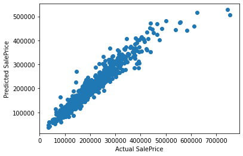

```python
traindf = totaldf[totaldf['SalePrice'].isna() == False]
testdf = totaldf[totaldf['SalePrice'].isna() == True]

reg = LinearRegression()

predictors = traindf.columns.drop(['Id','SalePrice'])
target = 'SalePrice'
IDcol = ['Id','SalePrice']
modelfit(reg, traindf, testdf, predictors, target, IDcol, 'Reg.csv')
```

## Ridge

```python
def rmse_cv(model):
    rmse= np.sqrt(-cross_val_score(model, traindf[predictors], traindf[target],scoring="neg_mean_squared_error", cv = 5))
    return(rmse)
ridgereg = Ridge()
alphas = [0.05, 0.1, 0.3, 1, 3, 5, 10, 15]
cv_ridge = pd.Series([rmse_cv(Ridge(alpha = alpha)).mean()for alpha in alphas], index = alphas)
```

```python
cv_ridge.idxmin()
```

```
3.0
```

```
RMSE: 197573.33743326107
CV Score : Mean: 0.12021118888763878 | Min: 0.09468851301904783 | Max: 0.15383750867848503
```

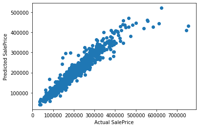

```python
ridgereg = Ridge(alpha=3)
modelfit(ridgereg, traindf, testdf, predictors, target, IDcol, 'RidgeReg.csv')
```

## Lasso

```python
lassoreg = LassoCV(alphas = [1, 0.1, 0.001, 0.0005]).fit(traindf, traindf[target])
rmse_cv(lassoreg).mean()
```

```
0.12102076279706808
```

```
RMSE: 197573.33936001087
CV Score : Mean: 0.11957946302962971 | Min: 0.09429562579697692 | Max: 0.1577812945062091
```

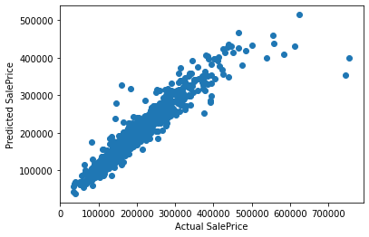

```python
modelfit(lassoreg, traindf, testdf, predictors, target, IDcol, 'LassoReg.csv')
```

```python
coef = pd.Series(lassoreg.coef_, index = traindf.columns.drop(['Id','SalePrice']))
print('The co-efficients Lasso elimaitated',sum(coef == 0))
```

```
The co-efficients Lasso elimaitated 127
```

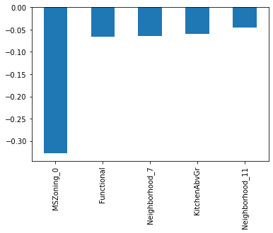

```python
coef.sort_values().head(5).plot(kind='bar')
```

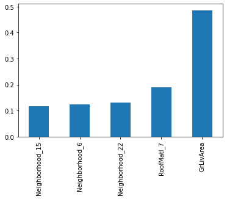

```python
coef.sort_values().tail(5).plot(kind='bar')
```

## XGBoost

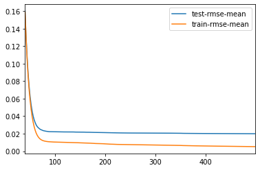

```python
dtrain = xgb.DMatrix(traindf, label = traindf[target])
dtest = xgb.DMatrix(testdf)
params = {'max_depth':2, 'eta':0.1}
model = xgb.cv(params, dtrain, num_boost_round=500, early_stopping_rounds=50)
model.loc[40:,['test-rmse-mean', 'train-rmse-mean']].plot()
```

```python
model_xgb = xgb.XGBRegressor(n_estimators=500, max_depth=2, learning_rate=0.1)
model_xgb.fit(traindf, traindf[target])
```

```
XGBRegressor(base_score=0.5, booster=None, colsample_bylevel=1,
             colsample_bynode=1, colsample_bytree=1, gamma=0, gpu_id=-1,
             importance_type='gain', interaction_constraints=None,
             learning_rate=0.1, max_delta_step=0, max_depth=2,
             min_child_weight=1, missing=nan, monotone_constraints=None,
             n_estimators=500, n_jobs=0, num_parallel_tree=1,
             objective='reg:squarederror', random_state=0, reg_alpha=0,
             reg_lambda=1, scale_pos_weight=1, subsample=1, tree_method=None,
             validate_parameters=False, verbosity=None)
```

```python
xgb_preds = np.expm1(model_xgb.predict(testdf))
solution = pd.DataFrame({'id':testdf.Id, 'SalePrice':xgb_preds})
solution.to_csv('xgb_sol.csv', index = False)
```

## Random Forest

```python
X = traindf.drop(target, axis = 1)
y = traindf[target]

X_train, X_test, y_train, y_test = train_test_split(X,y, test_size = 0.3, random_state = 42)
rfc = RandomForestRegressor()
rfc.fit(X_train,y_train)
```

```
RandomForestRegressor(bootstrap=True, criterion='mse', max_depth=None,
                      max_features='auto', max_leaf_nodes=None,
                      min_impurity_decrease=0.0, min_impurity_split=None,
                      min_samples_leaf=1, min_samples_split=2,
                      min_weight_fraction_leaf=0.0, n_estimators=10,
                      n_jobs=None, oob_score=False, random_state=None,
                      verbose=0, warm_start=False)
```

```python
parameters = {'n_estimators':np.arange(10,50)}
rfc_gs = GridSearchCV(rfc, parameters,cv=5)
rfc_gs.fit(X_train,y_train)
print(rfc_gs.best_params_,rfc_gs.best_score_)
```

```
{'n_estimators': 38} 0.8498470429513962
```

```
RMSE: 197573.33196983603
CV Score : Mean: 0.14009769281643836 | Min: 0.11038730782706675 | Max: 0.17116918492657063
```

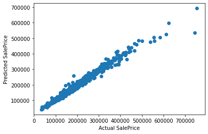

```python
rfc = RandomForestRegressor(n_estimators = 35)
modelfit(rfc, traindf, testdf, predictors, target, IDcol, 'RFCReg.csv')
```

## Decission Tree

```python
X_train, X_test, y_train, y_test = train_test_split(X,y, test_size = 0.3, random_state = 42)
dec = DecisionTreeRegressor()
parameters = {'min_samples_leaf':np.arange(1,3),'min_samples_split':np.arange(2,5)}
dec_gs = GridSearchCV(dec, parameters,cv=5)
dec_gs.fit(X_train,y_train)
print(dec_gs.best_params_,dec_gs.best_score_)
```

```
{'min_samples_leaf': 2, 'min_samples_split': 3} 0.6869900427227276
```

```python
dec = DecisionTreeRegressor(min_samples_leaf =2, min_samples_split= 4)
```

```
RMSE: 197573.32636683952
CV Score : Mean: 0.1903915779261653 | Min: 0.1567879493633556 | Max: 0.229173366433877
```

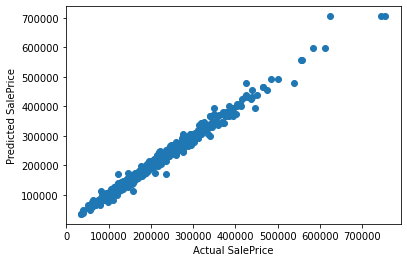

```python
modelfit(dec, traindf, testdf, predictors, target, IDcol, 'DECReg.csv')
```

## Elastic net

```python
elasticreg = ElasticNet()
alphas = [0.0001, 0.001, 0.01, 0.05, 0.1, 0.3, 1, 3, 5]
l1_ratios = [n/20 for n in range(21)]
params = {'alpha':alphas, 'l1_ratio':l1_ratios}
elastic_gs = GridSearchCV(elasticreg, params,cv=5)
elastic_gs.fit(X_train,y_train)
print(elastic_gs.best_params_,elastic_gs.best_score_)
```

```
{'alpha': 0.001, 'l1_ratio': 0.2} 0.8939825231051346
```

```python
elasticreg = ElasticNet(alpha=0.001, l1_ratio = 0.2)
```

```
RMSE: 197573.33803319992
CV Score : Mean: 0.11814863741482187 | Min: 0.093168293261737 | Max: 0.15296780609799937
```

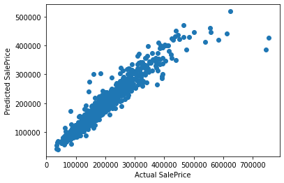

```python
modelfit(elasticreg, traindf, testdf, predictors, target, IDcol, 'ElasticReg.csv')
```